# Introduction and Purpose

The South African bond markets return contain the yield to maturity rates. This is the annualised rate of return to an investor who buys the bond and holds it until maturity. This is a standard measure of the total rate of return. This rate is viewed as a measure of the average rate of return that will be earned on a bond if it is bought now and held until it matures.Bonds are the most well-known type of fixed income instruments. They are issued by governments or businesses and pay interest on a predetermined schedule. In contrast to equities, the majority of fixed income products, including bonds, trade rarely.

The purpose of this document is to conduct an analysis of the South African bond market by investigating its volatility using the GARCH models. The project analyses the data and investigates the presence of conditional heteroskedasicity in the SA bond yields market.

```r
library(esquisse)
#esquisser(mtcars)
library(dplyr)
```

```r
library(ggplot2)

# ============== Preamble to load packages ========================== #
if(!require("devtools")){install_github("devtools")}
library(devtools)
# Install pacman to handle installations
install_github("trinker/pacman")
```

```
## Skipping install of 'pacman' from a github remote, the SHA1 (ace09364) has not changed since last install.
##   Use `force = TRUE` to force installation
```

```r
devtools::install_github("KevinKotze/tsm")
```

```r
# Install the required packages in elagant approach
pacman::p_load(
    "tidyverse",
    "devtools",
    "rugarch",
    "forecast",
    "tbl2xts",
    "lubridate",
    "PerformanceAnalytics",
    "ggthemes",
    "robustbase",
    "tbl2xts",
    "ggplot2",
    "ggthemes",
    "robustbase",
    "fmxdat",
    "extrafont",
    "TTR",
    "naniar",
    "readr",
    "dplyr",
    "tidyr",
    "rmsfuns",
    "naniar",
    "Texevier",
    "reshape2",
    "xts",
    "readr",
    "viridis",
    "viridisLite",
    "rugarch",
    "quantmod",
    "wesanderson",
    "MTS",
    "robustbase",
    "rmgarch",
    "forecast",
    "fGarch",
    "tsm",
    "ccgarch",
    "tseries",
    "xlsx",
    "gdata",
    "readxl",
    "xtable",
    "knitr")
```

```
##
##  C:\Users\Dell\AppData\Local\Temp\RtmpwX5fI6\downloaded_packages
```

```
##
## xlsx installed
```

```r
knitr::opts_chunk$set(out.height=400, out.width=800, fig.width=6, fig.height=3)
knitr::opts_chunk$set(warning = FALSE, message = FALSE)
```

# Data

```r
SA_bonds <- read_rds("data/SA_Bonds.rds") # SA bond 2 year, 3 month and 10 year
ZA_Infl <- read_rds("data/ZA_Infl.rds") # Inflation in South Africa (High inflation rate, leads to bond holders requiring higher  returns off bonds and thus )
IV <- read_rds("data/IV.rds") # Volatility index
usdzar <- read_rds("data/usdzar.rds")
```

```r
library(readxl)
X2yr_bonds <- read_excel("data/2yr_bonds.xlsx",
    col_types = c("date", "numeric", "numeric",
        "numeric", "numeric",
        "numeric"))
View(X2yr_bonds)
```

```r
library(readxl)
X10yr_bonds <- read_excel("data/10yr_bonds.xlsx",
    col_types = c("date", "numeric", "numeric",
        "numeric", "numeric",
        "numeric"))
View(X10yr_bonds)
```

```r
#library("writexl")
#write_xlsx(ZA_Infl,"D:\\A FM Project Bonds\\INF.xlsx")
```

```r
# transformation: reshape to plot
#Change dataset into time series
xts.SA_bonds <- tbl_xts(SA_bonds)
str(xts.SA_bonds)
```

```
## An 'xts' object on 1999-12-06/2021-10-29 containing:
##   Data: num [1:5715, 1:3] 11.3 11.3 11.3 11.3 11.3 ...
##  - attr(*, "dimnames")=List of 2
##   ..$ : NULL
##   ..$ : chr [1:3] "SA_3M" "ZA_10Yr" "ZA_2Yr"
##   Indexed by objects of class: [Date] TZ: UTC
##   xts Attributes:
##  NULL
```

```r
t1 <- head(xts.SA_bonds)
tail(xts.SA_bonds)
```

```
##            SA_3M ZA_10Yr ZA_2Yr
## 2021-10-22 3.683   9.922  5.483
## 2021-10-25 3.683   9.887  5.460
## 2021-10-26 3.683   9.845  5.461
## 2021-10-27 3.683  10.086  5.482
## 2021-10-28 3.683  10.171  5.553
## 2021-10-29 3.683  10.196  5.606
```

```r
kable(t1, caption = "SA bond yield rates")
```

SA bond yield rates

| SA_3M | ZA_10Yr | ZA_2Yr |
| --- | --- | --- |
| 11.278 | 14.032 | 12.743 |
| 11.278 | 14.002 | 12.700 |
| 11.289 | 14.120 | 12.776 |
| 11.300 | 14.058 | 12.719 |
| 11.300 | 13.975 | 12.698 |
| 11.289 | 13.952 | 12.651 |

```r
xts.2yr <- tbl_xts(X2yr_bonds)
str(xts.2yr)
```

```
## An 'xts' object on 1990-01-01/2021-10-29 containing:
##   Data: num [1:8305, 1:5] 7.84 7.88 7.93 7.91 7.88 ...
##  - attr(*, "dimnames")=List of 2
##   ..$ : NULL
##   ..$ : chr [1:5] "US_2yr" "Nigeria_2yr" "Brazil_2yr" "ZA_2yr" ...
##   Indexed by objects of class: [POSIXct,POSIXt] TZ: UTC
##   xts Attributes:
##  NULL
```

```r
head(xts.2yr)
```

```
##            US_2yr Nigeria_2yr Brazil_2yr ZA_2yr UK_2yr
## 1990-01-01  7.841          NA         NA     NA     NA
## 1990-01-02  7.875          NA         NA     NA     NA
## 1990-01-03  7.927          NA         NA     NA     NA
## 1990-01-04  7.910          NA         NA     NA     NA
## 1990-01-05  7.885          NA         NA     NA     NA
## 1990-01-08  7.893          NA         NA     NA     NA
```

```r
xts.10yr <- tbl_xts(X10yr_bonds)
str(xts.10yr)
```

```
## An 'xts' object on 1990-01-01/2021-10-29 containing:
##   Data: num [1:8305, 1:5] 7.94 7.93 7.97 7.97 7.98 ...
##  - attr(*, "dimnames")=List of 2
##   ..$ : NULL
##   ..$ : chr [1:5] "US_10yr" "Nigeria_10yr" "Brazil_10yr" "ZA_10yr" ...
##   Indexed by objects of class: [POSIXct,POSIXt] TZ: UTC
##   xts Attributes:
##  NULL
```

```r
head(xts.10yr)
```

```
##            US_10yr Nigeria_10yr Brazil_10yr ZA_10yr UK_10yr
## 1990-01-01   7.935           NA          NA      NA      NA
## 1990-01-02   7.930           NA          NA      NA      NA
## 1990-01-03   7.974           NA          NA      NA      NA
## 1990-01-04   7.972           NA          NA      NA      NA
## 1990-01-05   7.984           NA          NA      NA      NA
## 1990-01-08   8.012           NA          NA      NA      NA
```

```r
xts.IV <- tbl_xts(IV)
xts.ZA_Infl <- tbl_xts(ZA_Infl)
```

## Visualise the data

The Yield of a bond represents the money lent. The higher the yield the higher the return on the investment. The graph above shows the yield curves for the 3 month, 2 year and 10 year maturity. A significant decline is seen during the 2008 financial crisis as well as during the 2020 as caused by the COVID-19 pandemic. However, one notices a rise on the mid and long term bonds, while the short term (3M) remains at a constant rate. Usually yields with close maturities are relatively close to each other and may move together in the same fashion as seen the diagram below.

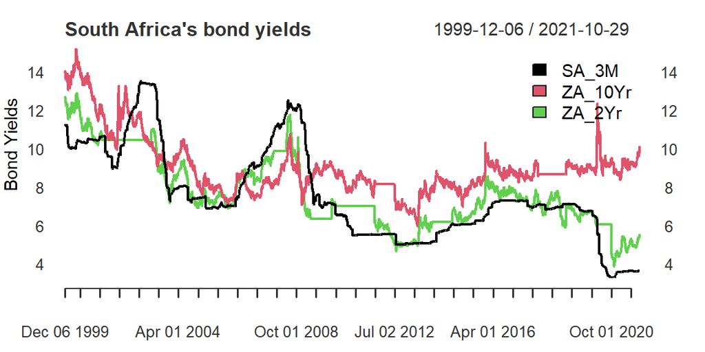

```r
asset.names <- colnames(xts.SA_bonds)
plot.xts(xts.SA_bonds, legend.loc = "topright", xlim = "bond yield", grid.col = "white", main = "South Africa's bond yields", ylab = "Bond Yields")
```

To compare the performance SA 2 Year bond yields to that of the US, UK, Brazil and Nigeria, the graph below shows this. The US and UK bond market tend to move with each other, while Nigeria’s bond yields are very high. The graph indicates different volatility processes.

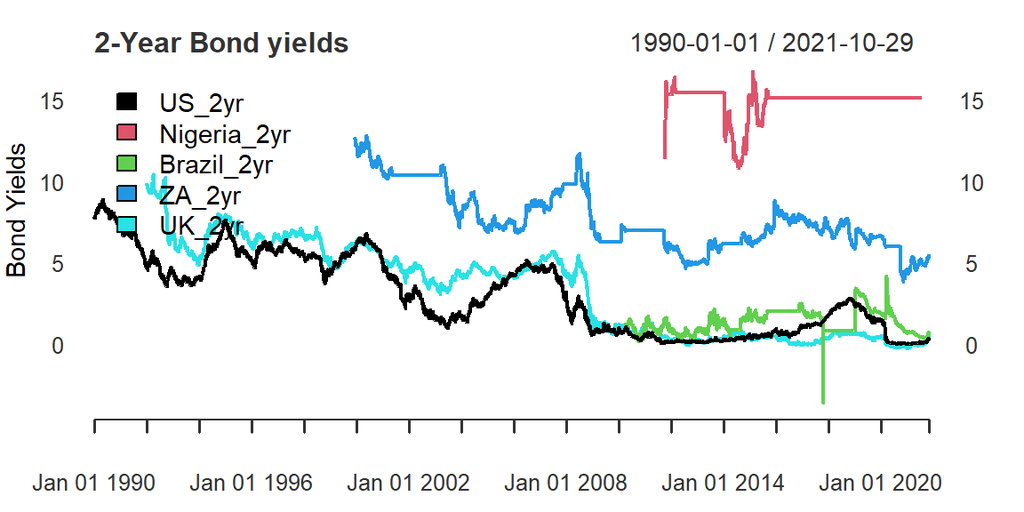

```r
#Plot Bond yields of 2-year
asset.names <- colnames(xts.2yr)
plot.xts(xts.2yr, legend.loc = "topleft", xlim = "bond yield", grid.col = "white", main = "2-Year Bond yields", ylab = "Bond Yields")
```

A similar pattern is seen in the 10 year bond yields.

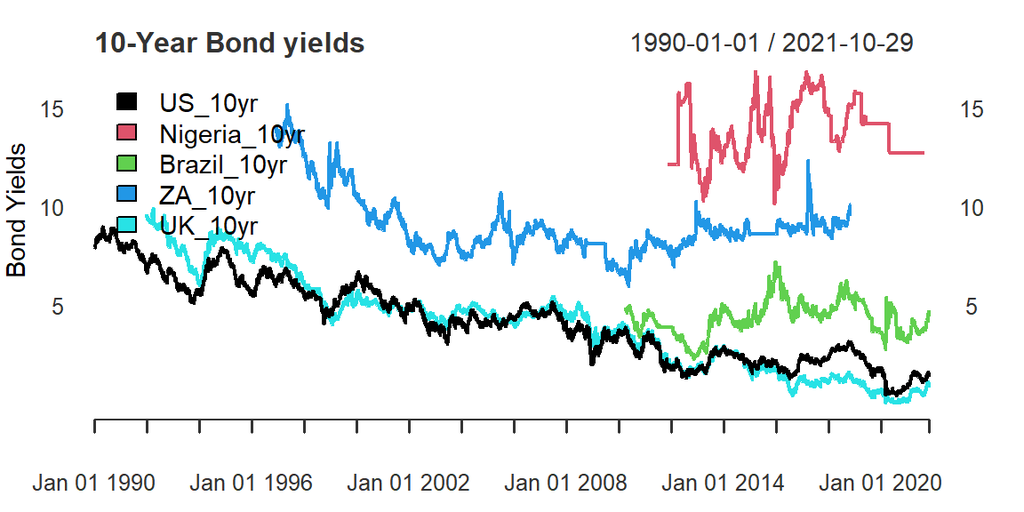

```r
#Plot Bond yields of 10-year
asset.names <- colnames(xts.10yr)
plot.xts(xts.10yr, legend.loc = "topleft", xlim = "bond yield", grid.col = "white", main = "10-Year Bond yields", ylab = "Bond Yields")
```

Volatility index

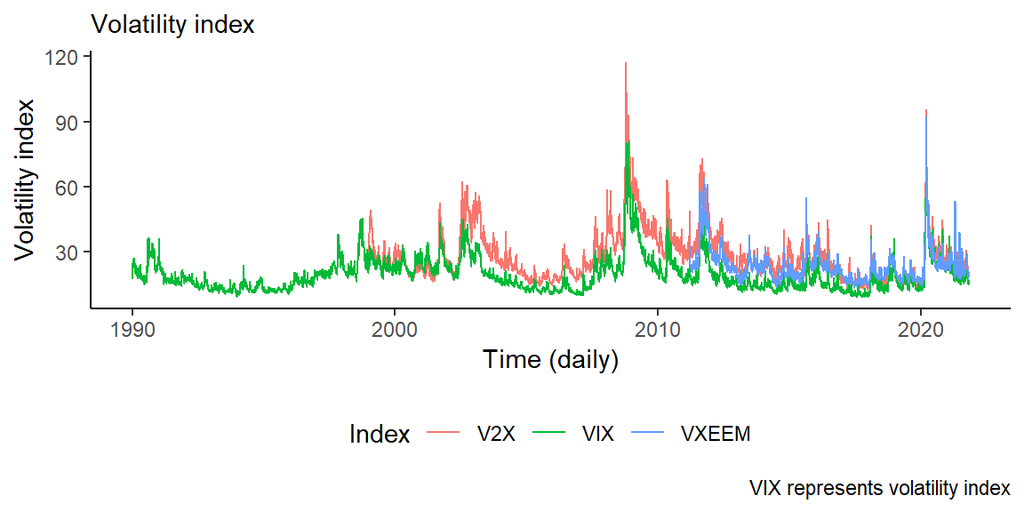

```r
p1 <- IV %>%
 ggplot() +
 aes(x = date, y = Price, colour = Name) +
 geom_line(size = 0.5) +
 scale_color_hue(direction = 1) +
 labs(x = "Time (daily)", y = "Volatility index", subtitle = "Volatility index", caption = "VIX represents volatility index",
 color = "Index") +
 theme_classic() +
 theme(legend.position = "bottom")

print(p1)
```

ZA Inflation rate

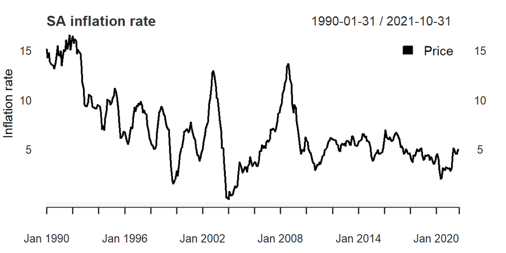

```r
plot.xts(xts.ZA_Infl, legend.loc = "topright", xlim = "bond yield", grid.col = "white", main = "SA inflation rate", ylab = "Inflation rate")
```

US AND ZAR Exchange rate

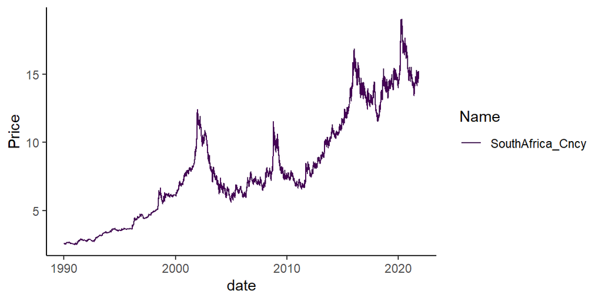

```r
ggplot(usdzar) +
  aes(x = date, y = Price, colour = Name) +
  geom_line(size = 0.5) +
  scale_color_viridis_d(option = "viridis", direction = 1) +
  theme_classic()
```

# 1. SA Yield Spreads

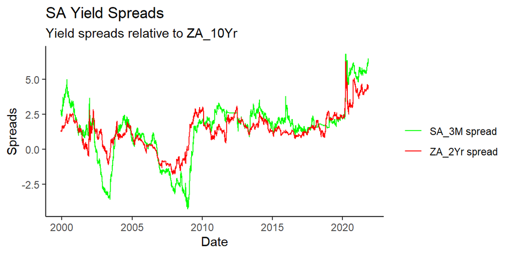

```r
ggplot(data = SA_bonds, aes(x = date)) +
  geom_line(aes(y =ZA_10Yr-SA_3M, colour = "SA_3M spread")) +
  geom_line(aes(y =ZA_10Yr-ZA_2Yr, colour = "ZA_2Yr spread")) +
  scale_colour_manual("",
                      breaks = c("SA_3M spread", "ZA_2Yr spread"),
                      values = c("SA_3M spread"="green", "ZA_2Yr spread"="red")) +
  xlab("Date") +
  scale_y_continuous("Spreads") +
  labs(title="SA Yield Spreads",
       subtitle = "Yield spreads relative to ZA_10Yr") + theme_classic()
```

# 2. Volatility

The annualised volatility and the yields move in a similar shape. The volatility calculation changes reduces the rate.

## Annualized volatility SA bonds

```r
#annualized volatility
annual_vol <- sqrt(xts.SA_bonds) * sd(xts.SA_bonds)
head(annual_vol)
```

```
##               SA_3M  ZA_10Yr   ZA_2Yr
## 1999-12-06 7.005293 7.813939 7.446395
## 1999-12-07 7.005293 7.805582 7.433821
## 1999-12-08 7.008708 7.838403 7.456031
## 1999-12-09 7.012122 7.821175 7.439379
## 1999-12-10 7.012122 7.798052 7.433235
## 1999-12-13 7.008708 7.791633 7.419466
```

```r
head(xts.SA_bonds)
```

```
##             SA_3M ZA_10Yr ZA_2Yr
## 1999-12-06 11.278  14.032 12.743
## 1999-12-07 11.278  14.002 12.700
## 1999-12-08 11.289  14.120 12.776
## 1999-12-09 11.300  14.058 12.719
## 1999-12-10 11.300  13.975 12.698
## 1999-12-13 11.289  13.952 12.651
```

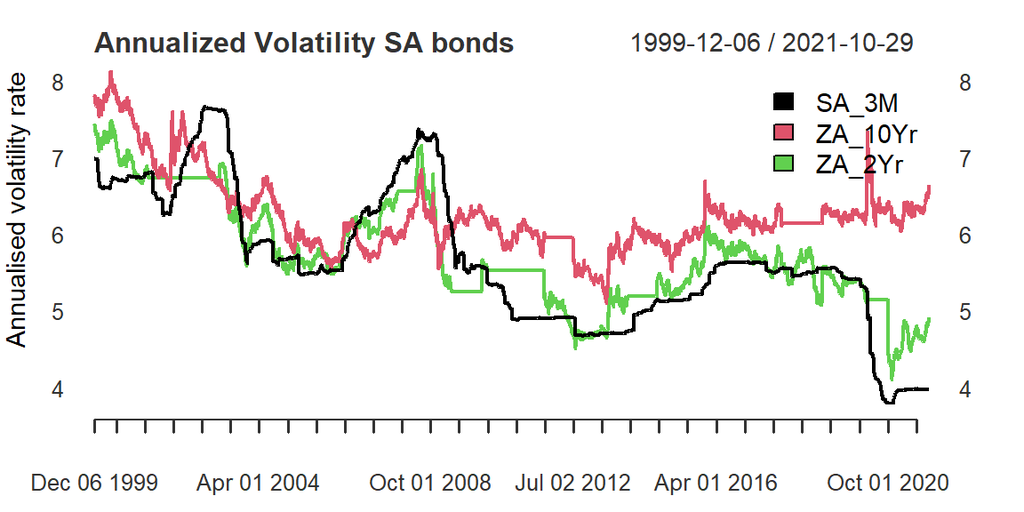

```r
plot.xts(annual_vol, legend.loc = "topright", ylab = "Annualised volatility rate", grid.col = "white", main = "Annualized Volatility SA bonds")
```

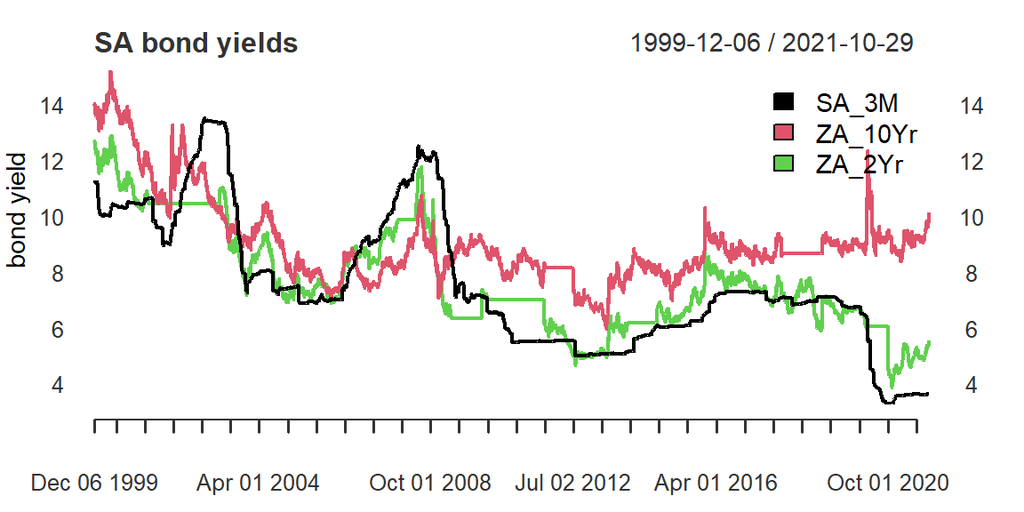

```r
asset.names <- colnames(xts.SA_bonds)
plot.xts(xts.SA_bonds, legend.loc = "topright", ylab = "bond yield", grid.col = "white", main = "SA bond yields")
```

## The rolling 1 and 3 month estimate of the annualised volatility

This is a visual of the time-variation in volatility. The assumption made here is that the number of trading days in a year equals to 252 days.

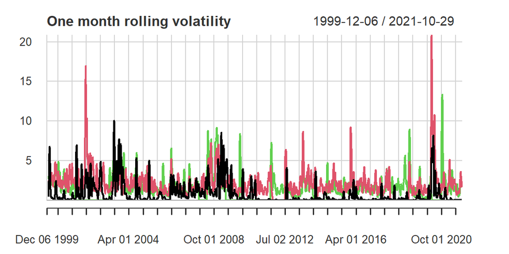

```r
# Compute the rolling 1 month estimate of annualized volatility
chart.RollingPerformance(R = xts.SA_bonds, width = 22,
     FUN = "sd.annualized", scale = 252, main = "One month rolling volatility")
```

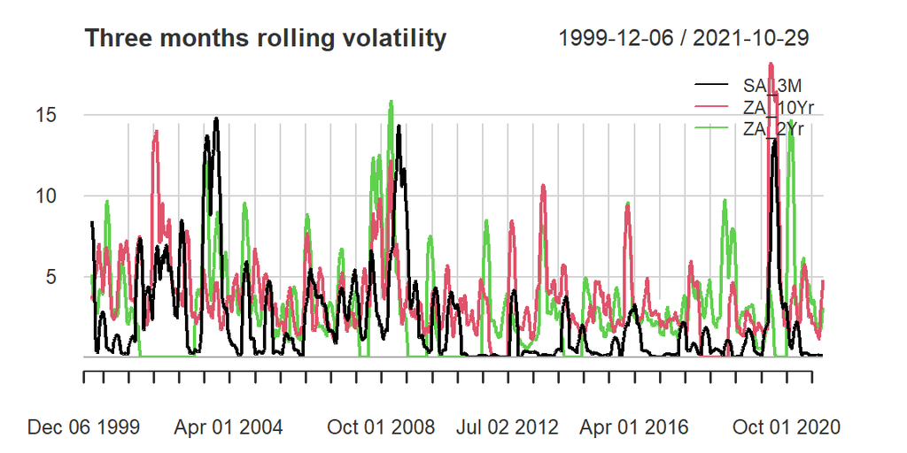

```r
# Compute the rolling 3 months estimate of annualized volatility
chart.RollingPerformance(R = xts.SA_bonds, width = 66,
     FUN = "sd.annualized", scale = 252, main = "Three months rolling volatility", legend.loc = "topright")
```

## Predictive errors

Calculation of the GARCH variance. We need the prediction errors.

Then a calculation of the positive autocorrelation can reflect the presence of volatility clusters. When this is above average, the value is above average.

```r
#Prediction errors
m <- mean(xts.SA_bonds)
# series of prediction errors
e <- xts.SA_bonds - m
```

The plot of the absolute value of the prediction errors

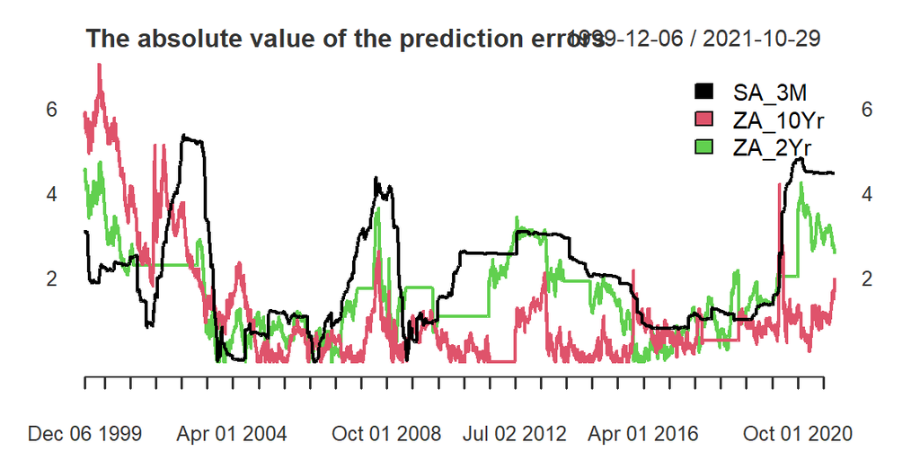

```r
par(mfrow = c(1,1), mar = c(3,2,2,2))
plot(abs(e), main = "The absolute value of the prediction errors", legend.loc = "topright", xlim = "bond yield", grid.col = "white" )
```

The plot for the absolute prediction errors.

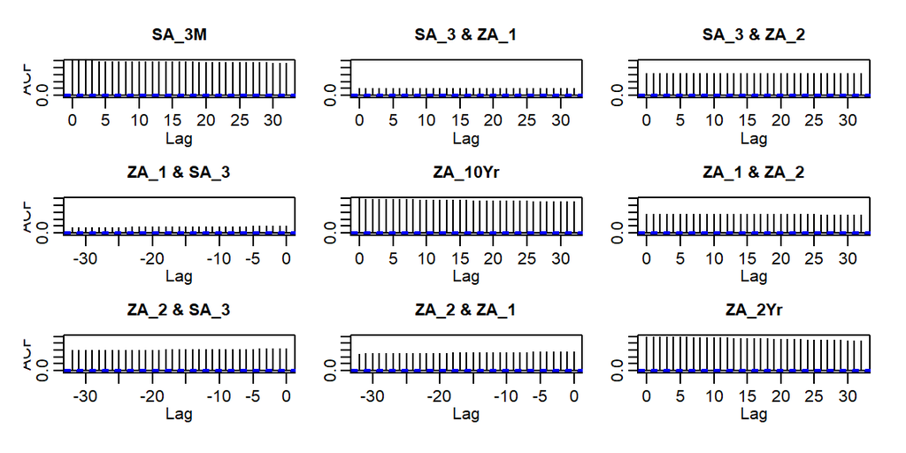

```r
acf(abs(e))
```

## Estimated Volatility and Residuals

## ZA_3M

```r
spec <- ugarchspec(distribution.model = "sstd")
fit_3M <- ugarchfit(xts.SA_bonds$SA_3M, spec = spec)
# Save the volatilities and the rescaled residuals
Volatilities_3M <- sigma(fit_3M)
Residuals_3M <- scale(residuals(fit_3M, standardize = TRUE)) * sd(xts.SA_bonds$SA_3M) + mean(xts.SA_bonds$SA_3M)
```

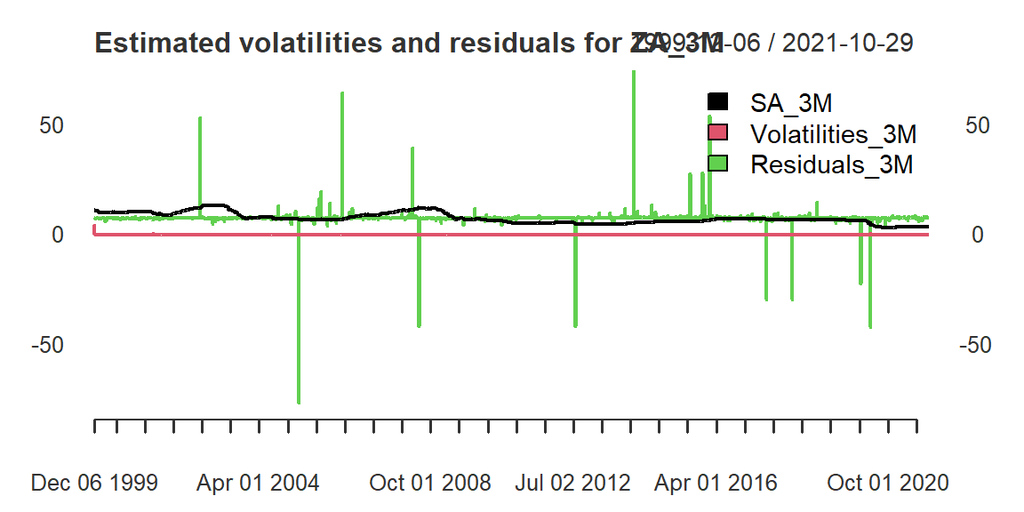

```r
# Plot the yield changes with the estimated volatilities and residuals
merge_1 <- merge.xts(xts.SA_bonds$SA_3M, Volatilities_3M, Residuals_3M)
plot.xts(merge_1, main = "Estimated volatilities and residuals for ZA_3M", legend.loc = "topright", grid.col = "white", width = 20)
```

## ZA_2Yr

```r
spec <- ugarchspec(distribution.model = "norm")
fit_2Yr <- ugarchfit(xts.SA_bonds$ZA_2Yr, spec = spec)
# Save the volatilities and the rescaled residuals
volatilities_2Yr <- sigma(fit_2Yr)
residuals_2Yr <- scale(residuals(fit_2Yr, standardize = TRUE)) * sd(xts.SA_bonds$ZA_2Yr) + mean(xts.SA_bonds$ZA_2Yr)
```

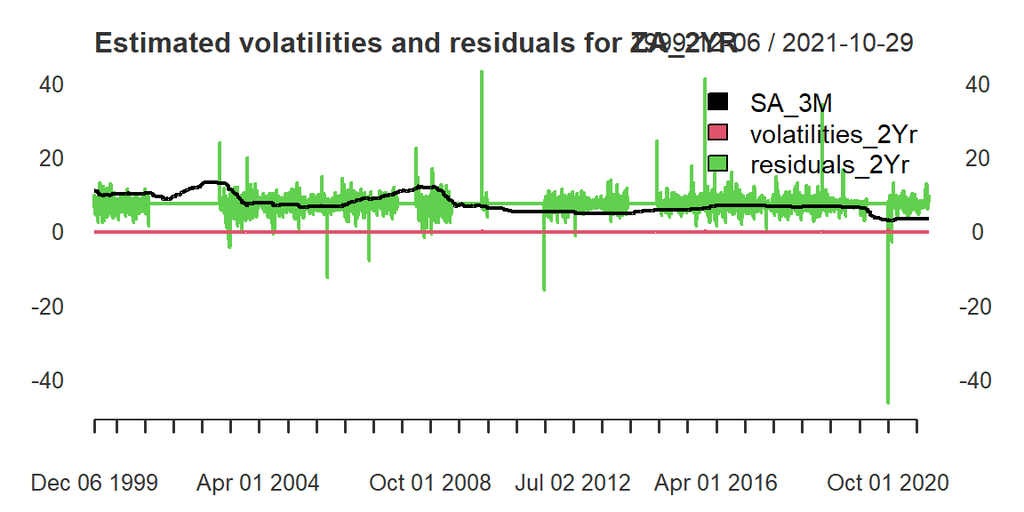

```r
# Plot the yield changes with the estimated volatilities and residuals
merge_2 <- merge.xts(xts.SA_bonds$SA_3M, volatilities_2Yr, residuals_2Yr)
plot.xts(merge_2, main = "Estimated volatilities and residuals for ZA_2YR", legend.loc = "topright", xlim = "bond yield", grid.col = "white", width = 20 )
```

## ZA 10Yr

```r
spec <- ugarchspec(distribution.model = "norm")
fit_10Yr <- ugarchfit(xts.SA_bonds$ZA_10Yr, spec = spec)
# Save the volatilities and the rescaled residuals
volatilities_10Yr <- sigma(fit_2Yr)
residuals_10Yr <- scale(residuals(fit_10Yr, standardize = TRUE)) * sd(xts.SA_bonds$ZA_10Yr) + mean(xts.SA_bonds$ZA_10Yr)
```

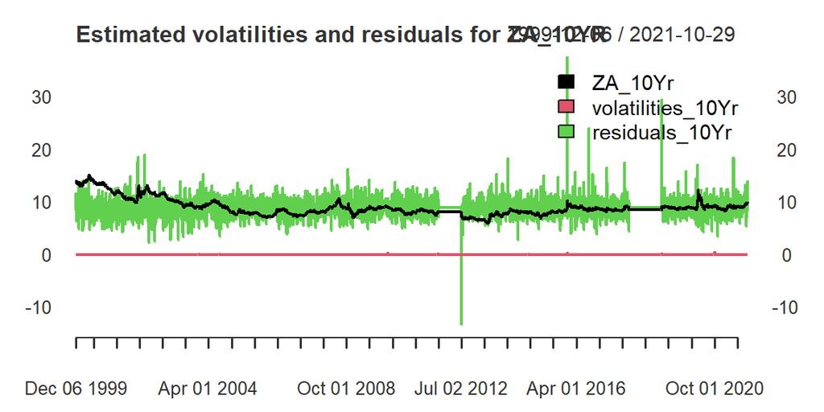

```r
# Plot the yield changes with the estimated volatilities and residuals
merge_3 <- merge.xts(xts.SA_bonds$ZA_10Yr, volatilities_10Yr, residuals_10Yr)
plot.xts(merge_3, main = "Estimated volatilities and residuals for ZA_10YR", legend.loc = "topright", xlim = "bond yield", grid.col = "white", width = 20)
```

# 3. Differentiated SA bond yields

A calculation of the yield levels through “differentiation” allows us to make the time series independent of time.

```r
# differentiate the time series
xts.SA_bonds_diff <- diff.xts(xts.SA_bonds)
#Remove NA variable
xts.SA_bonds_diff <- xts.SA_bonds_diff[-c(1),]
head(xts.SA_bonds_diff)
```

```
##             SA_3M ZA_10Yr ZA_2Yr
## 1999-12-07  0.000  -0.030 -0.043
## 1999-12-08  0.011   0.118  0.076
## 1999-12-09  0.011  -0.062 -0.057
## 1999-12-10  0.000  -0.083 -0.021
## 1999-12-13 -0.011  -0.023 -0.047
## 1999-12-14  0.000  -0.043 -0.029
```

## SA Yield changes

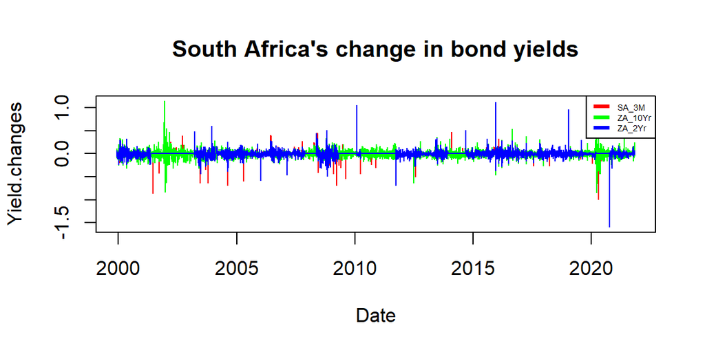

```r
Yield.changes  <- xts.SA_bonds_diff
plot.type  <- "single"
plot.type1  <- "multiple"
asset.names <- colnames(xts.SA_bonds_diff)
#Plot SA.bonds
plot.zoo(x = Yield.changes, plot.type = plot.type, xlab = "Date", col = rainbow(3), main = "South Africa's change in bond yields")
legend(x = "topright", legend = asset.names, cex = 0.45, lwd = 3, col = rainbow(3))
```

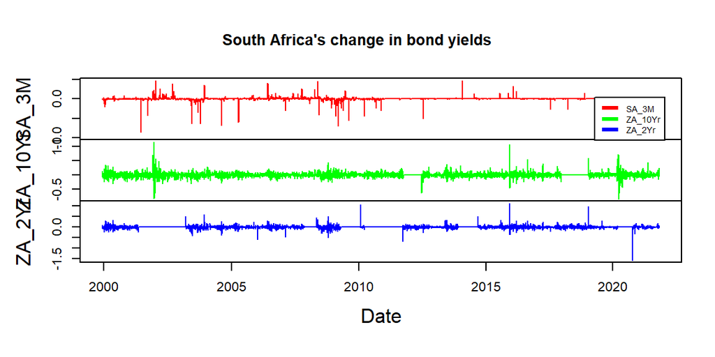

```r
plot.zoo(x = Yield.changes, plot.type = plot.type1, xlab = "Date", col = rainbow(3), main = "South Africa's change in bond yields")
legend(x = "topright", legend = asset.names, cex = 0.45, lwd = 3, col = rainbow(3))
```

## Test for autocorrelation

The graphs above show the yield changes in the bond. The graph shows the direction (positive or negative) is independent of the the previous days returns. The magnitude of the return is similar to the previous day’s return. Showing that during a volatile market or crisis the expected return will be similar to a turbulent tomorrow

To show this statistically one can measure autocorrelation which is used to show how the past depends on the future of a time series.

If the autocorrelation is close to 1, the next day’s value is close to today’s value, however, if it is close to 0 the next days value is unaffected by today’s value.

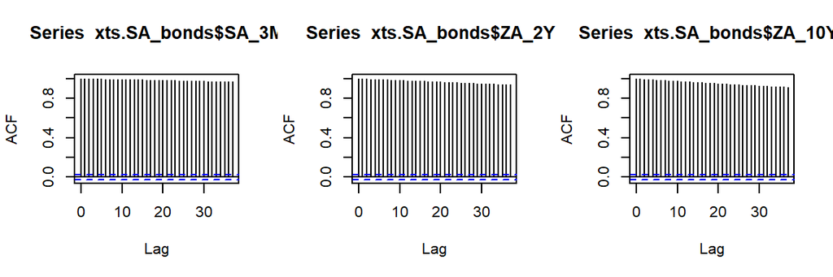

```r
# Plot the autocorrelations of the yield changes
par(mfrow=c(1,3))
acf_3M <- acf(xts.SA_bonds$SA_3M, na.action = na.pass)
acf_2Yr <- acf(xts.SA_bonds$ZA_2Yr, na.action = na.pass)
acf_10Yr <- acf(xts.SA_bonds$ZA_10Yr, na.action = na.pass)
mtext("Autocorrelation for 3M, 2Yr, 10Yr bond yield changes respectively", side = 3, line = -32, outer = TRUE)
```

The Autocorrelation figure shows each spike that rises above or falls below the dashed lines is considered to be statistically significant. This means the spike has a value that is significantly different from zero. If a spike is significantly different from zero, that is evidence of autocorrelation. A spike that’s close to zero is evidence against autocorrelation.

```r
Box.test(coredata(xts.SA_bonds$SA_3M), type = "Ljung-Box", lag = 12)
```

```
##
##  Box-Ljung test
##
## data:  coredata(xts.SA_bonds$SA_3M)
## X-squared = 68081, df = 12, p-value < 2.2e-16
```

```r
Box.test(coredata(xts.SA_bonds$ZA_2Yr), type = "Ljung-Box", lag = 12)
```

```
##
##  Box-Ljung test
##
## data:  coredata(xts.SA_bonds$ZA_2Yr)
## X-squared = 67315, df = 12, p-value < 2.2e-16
```

```r
Box.test(coredata(xts.SA_bonds$ZA_10Yr), type = "Ljung-Box", lag = 12)
```

```
##
##  Box-Ljung test
##
## data:  coredata(xts.SA_bonds$ZA_10Yr)
## X-squared = 66477, df = 12, p-value < 2.2e-16
```

# 4. GARCH model

The GARCH - A Generalized AutoRegressive Conditional Heteroskedasticity model is a tool used to handle changing volatility in financial time series data. The equation below shows the popular GARCH form that shows the volatility process. In words the equation means the “the current volatility
$$\sigma^2$$
is equal to the last day’s volatility
$$\sigma^2_{t-1}$$
and the last day’s return
$$\epsilon^2_{t-1}$$
, with estimated parameters
$$w,\alpha,\beta$$

## GARCH model specification

This is a standard GARCH, (1,1) does a good job of dealing with second order persistence.

```r
# Note specify the mean (mu) and variance (sigma) models separately:
garch11 <-  ugarchspec(

    variance.model = list(model = c("sGARCH","gjrGARCH","eGARCH","fGARCH","apARCH")[1],

    garchOrder = c(1, 1)),

    mean.model = list(armaOrder = c(1, 0), include.mean = TRUE),

    distribution.model = c("norm", "snorm", "std", "sstd", "ged", "sged", "nig", "ghyp", "jsu")[1])
```

## 3 Month SA bond yields

```r
garchfit1 = ugarchfit(spec = garch11, data = xts.SA_bonds$SA_3M)
garchfit1
```

```
##
## *---------------------------------*
## *          GARCH Model Fit        *
## *---------------------------------*
##
## Conditional Variance Dynamics
## -----------------------------------
## GARCH Model  : sGARCH(1,1)
## Mean Model   : ARFIMA(1,0,0)
## Distribution : norm
##
## Optimal Parameters
## ------------------------------------
##         Estimate  Std. Error  t value Pr(>|t|)
## mu     13.139795    0.005862 2241.350        0
## ar1     0.999889    0.000118 8487.760        0
## omega   0.000113    0.000009   12.964        0
## alpha1  0.079111    0.013170    6.007        0
## beta1   0.887363    0.009263   95.800        0
##
## Robust Standard Errors:
##         Estimate  Std. Error  t value Pr(>|t|)
## mu     13.139795  154.196825 0.085214  0.93209
## ar1     0.999889    1.186271 0.842884  0.39929
## omega   0.000113    0.003421 0.033079  0.97361
## alpha1  0.079111    6.993656 0.011312  0.99098
## beta1   0.887363    4.513173 0.196616  0.84413
##
## LogLikelihood : 10338.12
##
## Information Criteria
## ------------------------------------
##
## Akaike       -3.6161
## Bayes        -3.6103
## Shibata      -3.6161
## Hannan-Quinn -3.6141
##
## Weighted Ljung-Box Test on Standardized Residuals
## ------------------------------------
```

[output cut: 40 more lines]

```
## Negative Sign Bias 0.68784 0.4916
## Positive Sign Bias 0.17016 0.8649
## Joint Effect       0.50220 0.9184
##
##
## Adjusted Pearson Goodness-of-Fit Test:
## ------------------------------------
##   group statistic p-value(g-1)
## 1    20     48791            0
## 2    30     72578            0
## 3    40     97053            0
## 4    50    121588            0
##
##
## Elapsed time : 0.8655682
```

[output not shown]

Model coefficients 3Month

|  | Estimate | Std. Error | t value | Pr(>\|t\|) |
| --- | --- | --- | --- | --- |
| mu | 13.1397951 | 0.0058624 | 2241.349703 | 0 |
| ar1 | 0.9998894 | 0.0001178 | 8487.760224 | 0 |
| omega | 0.0001132 | 0.0000087 | 12.964395 | 0 |
| alpha1 | 0.0791106 | 0.0131697 | 6.006997 | 0 |
| beta1 | 0.8873634 | 0.0092627 | 95.800145 | 0 |

The Weighted ARCH LM tests shows a high p-value, we do not reject the null hypothesis of no autocorrelation.

```r
infocriteria(garchfit1)
```

```
##
## Akaike       -3.616138
## Bayes        -3.610320
## Shibata      -3.616140
## Hannan-Quinn -3.614113
```

```
##
## please wait...calculating quantiles...
```

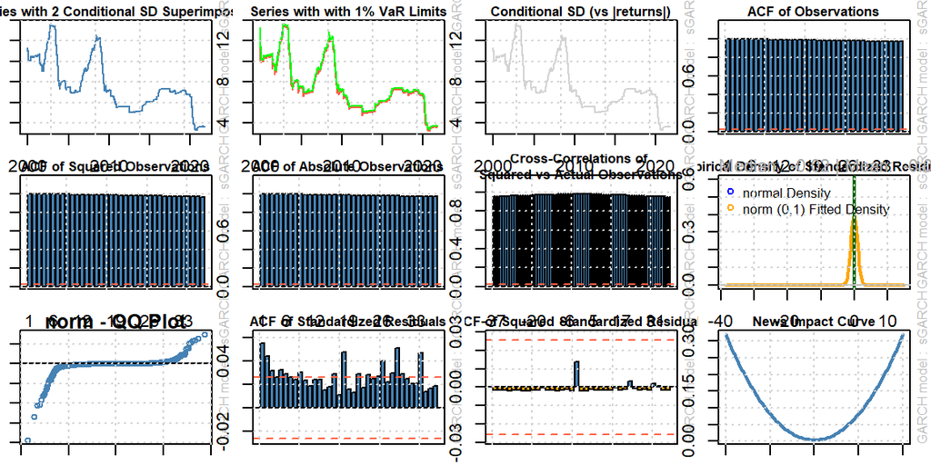

```r
par(mar=c(1,1,1,1))
plot(garchfit1, which = "all")
```

Conditional Variance

```r
sigma <- sigma(garchfit1) %>% xts_tbl()
colnames(sigma) <- c("date", "sigma")
sigma <- sigma %>% mutate(date = as.Date(date))
```

The conditional variance plot

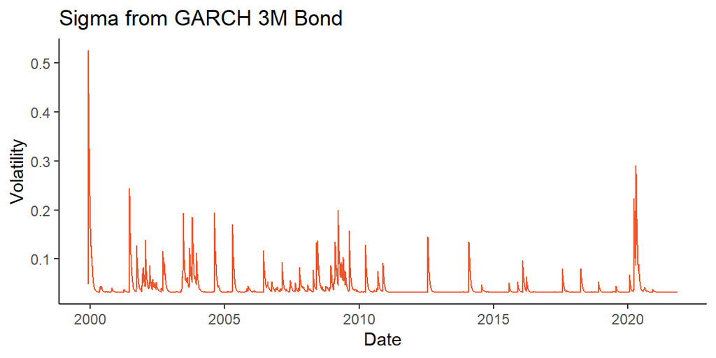

```r
ggplot(sigma) +
 aes(x = date, y = sigma) +
 geom_line(size = 0.5, colour = "#EF562D") +
 labs(x = "Date",
 y = "Volatility", title = "Sigma from GARCH 3M Bond") +
 theme_classic()
```

The red line is the actual volatility representation.

## 2 Year SA bond yields

```r
garchfit2 = ugarchfit(spec = garch11, data = xts.SA_bonds$ZA_2Yr)
garchfit2
```

```
##
## *---------------------------------*
## *          GARCH Model Fit        *
## *---------------------------------*
##
## Conditional Variance Dynamics
## -----------------------------------
## GARCH Model  : sGARCH(1,1)
## Mean Model   : ARFIMA(1,0,0)
## Distribution : norm
##
## Optimal Parameters
## ------------------------------------
##         Estimate  Std. Error   t value Pr(>|t|)
## mu     12.743001    0.061751  206.3603        0
## ar1     1.000000    0.000173 5793.3881        0
## omega   0.001338    0.000143    9.3707        0
## alpha1  0.211539    0.024548    8.6174        0
## beta1   0.547080    0.042963   12.7339        0
##
## Robust Standard Errors:
##         Estimate  Std. Error    t value Pr(>|t|)
## mu     12.743001    0.000407 31319.1257 0.000000
## ar1     1.000000    0.000269  3715.0772 0.000000
## omega   0.001338    0.001236     1.0832 0.278722
## alpha1  0.211539    0.093230     2.2690 0.023268
## beta1   0.547080    0.253102     2.1615 0.030657
##
## LogLikelihood : 7633.969
##
## Information Criteria
## ------------------------------------
##
## Akaike       -2.6698
## Bayes        -2.6640
## Shibata      -2.6698
## Hannan-Quinn -2.6678
##
## Weighted Ljung-Box Test on Standardized Residuals
## ------------------------------------
```

[output cut: 40 more lines]

```
## Negative Sign Bias 0.13371 0.8936
## Positive Sign Bias 0.05585 0.9555
## Joint Effect       0.11166 0.9904
##
##
## Adjusted Pearson Goodness-of-Fit Test:
## ------------------------------------
##   group statistic p-value(g-1)
## 1    20     11587            0
## 2    30     16745            0
## 3    40     21602            0
## 4    50     26313            0
##
##
## Elapsed time : 0.527266
```

```r
#slotNames(garchfit1)
#names(garchfit1@fit)
#names(garchfit1@model)

# Use it now as follows:
garchfit2@fit$matcoef # Model coefficients.
```

```
##            Estimate   Std. Error     t value Pr(>|t|)
## mu     12.743001023 0.0617512325  206.360270        0
## ar1     1.000000010 0.0001726106 5793.388106        0
## omega   0.001338398 0.0001428287    9.370652        0
## alpha1  0.211538971 0.0245480011    8.617360        0
## beta1   0.547079792 0.0429625895   12.733864        0
```

```r
infocriteria(garchfit2)
```

```
##
## Akaike       -2.669806
## Bayes        -2.663987
## Shibata      -2.669807
## Hannan-Quinn -2.667780
```

```
##
## please wait...calculating quantiles...
```

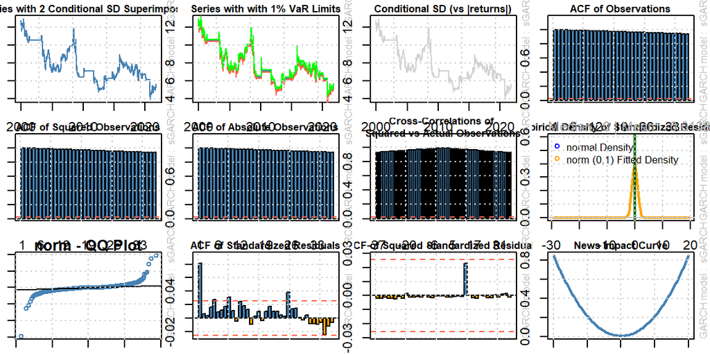

```r
par(mar=c(1,1,1,1))
plot(garchfit2, which = "all")
```

```r
garchfit3 = ugarchfit(spec = garch11, data = xts.SA_bonds$ZA_2Yr)
garchfit3
```

```
##
## *---------------------------------*
## *          GARCH Model Fit        *
## *---------------------------------*
##
## Conditional Variance Dynamics
## -----------------------------------
## GARCH Model  : sGARCH(1,1)
## Mean Model   : ARFIMA(1,0,0)
## Distribution : norm
##
## Optimal Parameters
## ------------------------------------
##         Estimate  Std. Error   t value Pr(>|t|)
## mu     12.743001    0.061751  206.3603        0
## ar1     1.000000    0.000173 5793.3881        0
## omega   0.001338    0.000143    9.3707        0
## alpha1  0.211539    0.024548    8.6174        0
## beta1   0.547080    0.042963   12.7339        0
##
## Robust Standard Errors:
##         Estimate  Std. Error    t value Pr(>|t|)
## mu     12.743001    0.000407 31319.1257 0.000000
## ar1     1.000000    0.000269  3715.0772 0.000000
## omega   0.001338    0.001236     1.0832 0.278722
## alpha1  0.211539    0.093230     2.2690 0.023268
## beta1   0.547080    0.253102     2.1615 0.030657
##
## LogLikelihood : 7633.969
##
## Information Criteria
## ------------------------------------
##
## Akaike       -2.6698
## Bayes        -2.6640
## Shibata      -2.6698
## Hannan-Quinn -2.6678
##
## Weighted Ljung-Box Test on Standardized Residuals
## ------------------------------------
```

[output cut: 40 more lines]

```
## Negative Sign Bias 0.13371 0.8936
## Positive Sign Bias 0.05585 0.9555
## Joint Effect       0.11166 0.9904
##
##
## Adjusted Pearson Goodness-of-Fit Test:
## ------------------------------------
##   group statistic p-value(g-1)
## 1    20     11587            0
## 2    30     16745            0
## 3    40     21602            0
## 4    50     26313            0
##
##
## Elapsed time : 0.5168881
```

```r
#slotNames(garchfit1)
#names(garchfit1@fit)
#names(garchfit1@model)

# Use it now as follows:
garchfit3@fit$matcoef  # Model coefficients.
```

```
##            Estimate   Std. Error     t value Pr(>|t|)
## mu     12.743001023 0.0617512325  206.360270        0
## ar1     1.000000010 0.0001726106 5793.388106        0
## omega   0.001338398 0.0001428287    9.370652        0
## alpha1  0.211538971 0.0245480011    8.617360        0
## beta1   0.547079792 0.0429625895   12.733864        0
```

```r
infocriteria(garchfit3)
```

```
##
## Akaike       -2.669806
## Bayes        -2.663987
## Shibata      -2.669807
## Hannan-Quinn -2.667780
```

```
##
## please wait...calculating quantiles...
```

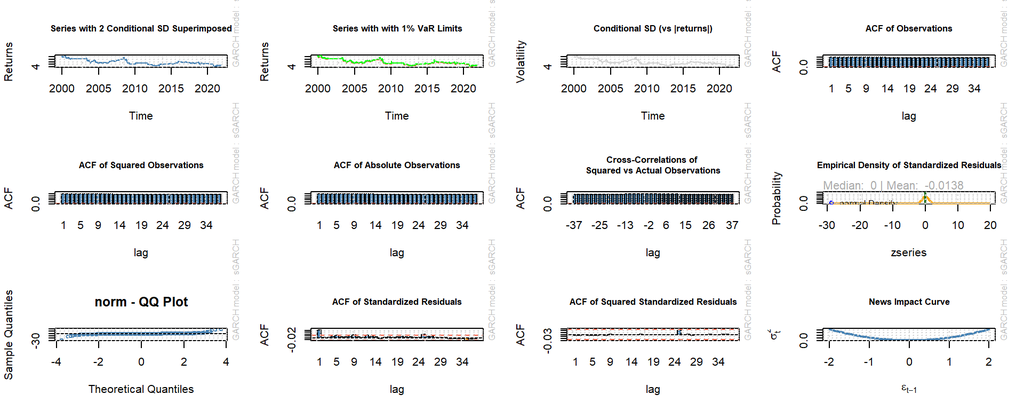

```r
plot(garchfit3, which = "all")
```

# 5. Multivariate GARCH model

## Model setup

```r
#estimate these univariate GARCH models using AR(1) GARCH(1,1) model and replicate the model 3 times because we have 3 year to maturity bonds.
uspec.n <- multispec(replicate(3, garch11))
```

```r
#Estimate the univariate GARCH models using multifit command
multf <- multifit(uspec.n, xts.SA_bonds)
multf
```

```
##
## *----------------------------*
## *     GARCH Multi-Fit        *
## *----------------------------*
## No. Assets :3
## GARCH Multi-Spec Type : Equal
## GARCH Model Spec
## --------------------------
## Model : sGARCH
## Exogenous Regressors in variance equation: none
##
## Mean Equation :
## Include Mean :  1
## AR(FI)MA Model : (1,d,0)
## GARCH-in-Mean :  FALSE
## Exogenous Regressors in mean equation: none
## Conditional Distribution:  norm
##
## GARCH Model Fit
## --------------------------
## Optimal Parameters:
##               SA_3M    ZA_10Yr     ZA_2Yr
## mu         13.13980   14.03201   12.74300
## ar1         0.99989    1.00000    1.00000
## omega       0.00011    0.00036    0.00134
## alpha1      0.07911    0.13822    0.21154
## beta1       0.88736    0.81159    0.54708
## Log-Lik 10338.11571 7133.00753 7633.96942
```

## Specification of the DCC model

```r
#This models the univariate volatilities as per uspec.n and the complex dynamic structure of the correlation matrix of dccorder c(1,1)
spec1 <- dccspec(uspec = uspec.n, dccOrder = c(1, 1), distribution = 'mvnorm')
```

## Model Estimation

```r
fit1 <-  dccfit(spec1, data = xts.SA_bonds, fit.control = list(eval.se =TRUE), fit = multf)
fit1
```

```
##
## *---------------------------------*
## *          DCC GARCH Fit          *
## *---------------------------------*
##
## Distribution         :  mvnorm
## Model                :  DCC(1,1)
## No. Parameters       :  20
## [VAR GARCH DCC UncQ] : [0+15+2+3]
## No. Series           :  3
## No. Obs.             :  5715
## Log-Likelihood       :  25902.82
## Av.Log-Likelihood    :  4.53
##
## Optimal Parameters
## -----------------------------------
##                   Estimate  Std. Error    t value Pr(>|t|)
## [SA_3M].mu       13.139795   90.776241 1.4475e-01 0.884909
## [SA_3M].ar1       0.999889    0.698361 1.4318e+00 0.152211
## [SA_3M].omega     0.000113    0.002013 5.6208e-02 0.955176
## [SA_3M].alpha1    0.079111    4.114501 1.9227e-02 0.984660
## [SA_3M].beta1     0.887363    2.655654 3.3414e-01 0.738273
## [ZA_10Yr].mu     14.032011    0.000340 4.1287e+04 0.000000
## [ZA_10Yr].ar1     1.000000    0.000372 2.6897e+03 0.000000
## [ZA_10Yr].omega   0.000358    0.000218 1.6422e+00 0.100557
## [ZA_10Yr].alpha1  0.138224    0.045056 3.0678e+00 0.002157
## [ZA_10Yr].beta1   0.811595    0.055597 1.4598e+01 0.000000
## [ZA_2Yr].mu      12.743001    0.000444 2.8706e+04 0.000000
## [ZA_2Yr].ar1      1.000000    0.000255 3.9202e+03 0.000000
## [ZA_2Yr].omega    0.001338    0.001168 1.1456e+00 0.251962
## [ZA_2Yr].alpha1   0.211539    0.093685 2.2580e+00 0.023946
## [ZA_2Yr].beta1    0.547080    0.232256 2.3555e+00 0.018498
## [Joint]dcca1      0.032678    0.029828 1.0956e+00 0.273268
## [Joint]dccb1      0.962065    0.034221 2.8114e+01 0.000000
##
## Information Criteria
## ---------------------
##
## Akaike       -9.0579
## Bayes        -9.0346
## Shibata      -9.0579
## Hannan-Quinn -9.0498
##
##
## Elapsed time : 3.948619
```

## Model based time varying covariance and correlation matrices

```r
covariance1 <- rcov(fit1)
dim(covariance1)
```

```
## [1]    3    3 5715
```

```r
correlation1 <- rcor(fit1)
dim(correlation1)
```

```
## [1]    3    3 5715
```

This is a three dimensional object, the two dimensions have 3 elements each and the third as 5715 elements. This means that 5715 of data is stored in a 3x3 matrix.

A view of the matrix for the last day

```r
covariance1[,,dim(covariance1)[3]]
```

```
##                 SA_3M       ZA_10Yr       ZA_2Yr
## SA_3M    1.006260e-03 -3.908677e-05 1.980127e-05
## ZA_10Yr -3.908677e-05  1.209253e-02 3.528050e-03
## ZA_2Yr   1.980127e-05  3.528050e-03 4.161398e-03
```

```r
correlation1[,,dim(correlation1)[3]]
```

```
##                SA_3M     ZA_10Yr      ZA_2Yr
## SA_3M    1.000000000 -0.01120511 0.009676497
## ZA_10Yr -0.011205107  1.00000000 0.497343464
## ZA_2Yr   0.009676497  0.49734346 1.000000000
```

### Plot of the three correlations between the three bond yields:

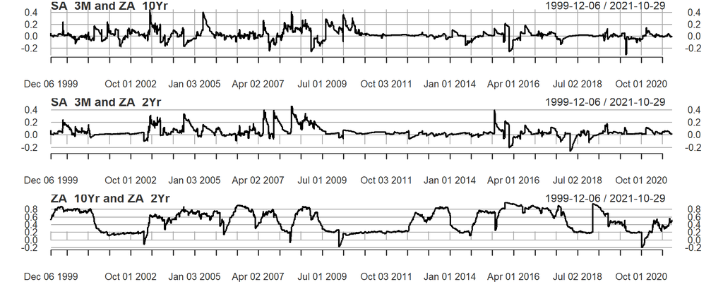

```r
par(mfrow=c(3,1))  # this creates a frame with 3 windows to be filled by plots
plot(as.xts(correlation1[1,2,]),main="SA_3M and ZA_10Yr")
plot(as.xts(correlation1[1,3,]),main="SA_3M and ZA_2Yr")
plot(as.xts(correlation1[2,3,]),main="ZA_10Yr and ZA_2Yr")
```

### Covariance

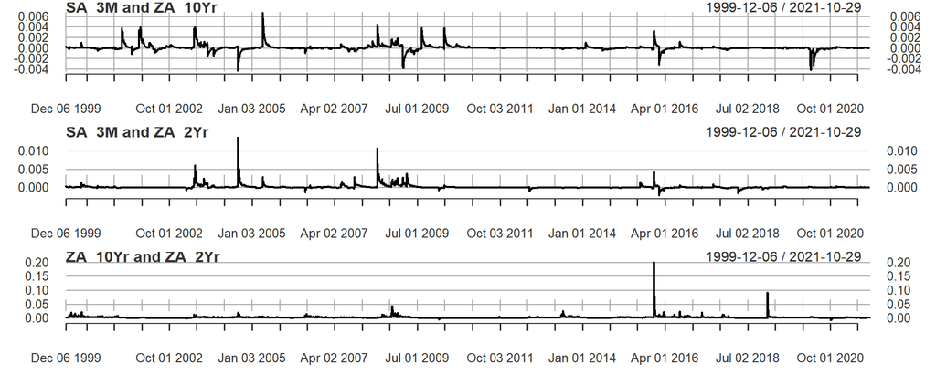

```r
par(mfrow=c(3,1))  # this creates a frame with 3 windows to be filled by plots
plot(as.xts(covariance1[1,2,]),main="SA_3M and ZA_10Yr")
plot(as.xts(covariance1[1,3,]),main="SA_3M and ZA_2Yr")
plot(as.xts(covariance1[2,3,]),main="ZA_10Yr and ZA_2Yr")
```

### Forecasts

```r
#Use the estimated model to produce forecats for the covariance or correlation matrix
dccf1 <- dccforecast(fit1, n.ahead = 10)
dccf1
```

```
##
## *---------------------------------*
## *       DCC GARCH Forecast        *
## *---------------------------------*
##
## Distribution         :  mvnorm
## Model                :  DCC(1,1)
## Horizon              :  10
## Roll Steps           :  0
## -----------------------------------
##
## 0-roll forecast:
##
## First 2 Correlation Forecasts
## , , 1
##
##           [,1]     [,2]     [,3]
## [1,]  1.000000 -0.01118 0.007407
## [2,] -0.011179  1.00000 0.494889
## [3,]  0.007407  0.49489 1.000000
##
## , , 2
##
##           [,1]     [,2]     [,3]
## [1,]  1.000000 -0.01099 0.007606
## [2,] -0.010993  1.00000 0.494934
## [3,]  0.007606  0.49493 1.000000
##
## . . .
## . . .
##
## Last 2 Correlation Forecasts
## , , 1
##
##           [,1]      [,2]     [,3]
## [1,]  1.000000 -0.009716 0.008968
## [2,] -0.009716  1.000000 0.495242
## [3,]  0.008968  0.495242 1.000000
##
## , , 2
##
##           [,1]      [,2]     [,3]
## [1,]  1.000000 -0.009537 0.009158
## [2,] -0.009537  1.000000 0.495285
## [3,]  0.009158  0.495285 1.000000
```

## Correlation forecast

```r
Rf <- dccf1@mforecast$R
```

```r
corf_310 <- Rf[[1]][1,2,]  # Correlation forecasts between SA_3M and ZA_10Yr
corf_32 <- Rf[[1]][1,3,]  # Correlation forecasts between SA_3M and ZA_2Yr
corf_102 <- Rf[[1]][2,3,]  # Correlation forecasts between ZA_10Yr and ZA_2Yr
```

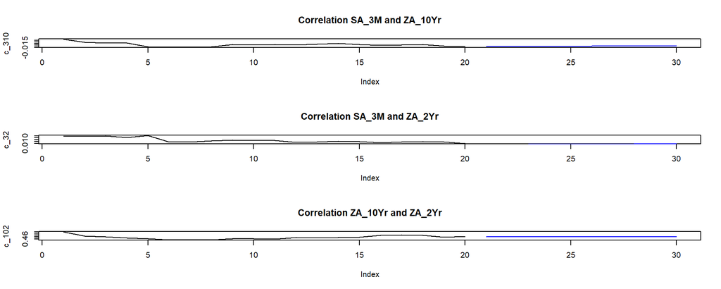

```r
par(mfrow=c(3,1))  # this creates a frame with 3 windows to be filled by plots
c_310 <- c(tail(correlation1[1,2,],20),rep(NA,10))  # gets the last 20 correlation observations
cf_310 <- c(rep(NA,20),corf_310) # gets the 10 forecasts
plot(c_310,type = "l",main="Correlation SA_3M and ZA_10Yr")
lines(cf_310,type = "l", col = "blue")

c_32 <- c(tail(correlation1[1,3,],20),rep(NA,10))  # gets the last 20 correlation observations
cf_32 <- c(rep(NA,20),corf_32) # gets the 10 forecasts
plot(c_32,type = "l",main="Correlation SA_3M and ZA_2Yr")
lines(cf_32,type = "l", col = "blue")

c_102 <- c(tail(correlation1[2,3,],20),rep(NA,10))  # gets the last 20 correlation observations
cf_102 <- c(rep(NA,20),corf_102) # gets the 10 forecasts
plot(c_102,type = "l",main="Correlation ZA_10Yr and ZA_2Yr")
lines(cf_102,type = "l", col = "blue")
```

DCC Forecast

```r
#Use the estimated model to produce forecast for the covariance or correlation matrix
dccf1 <- dccforecast(fit1, n.ahead = 10)
```

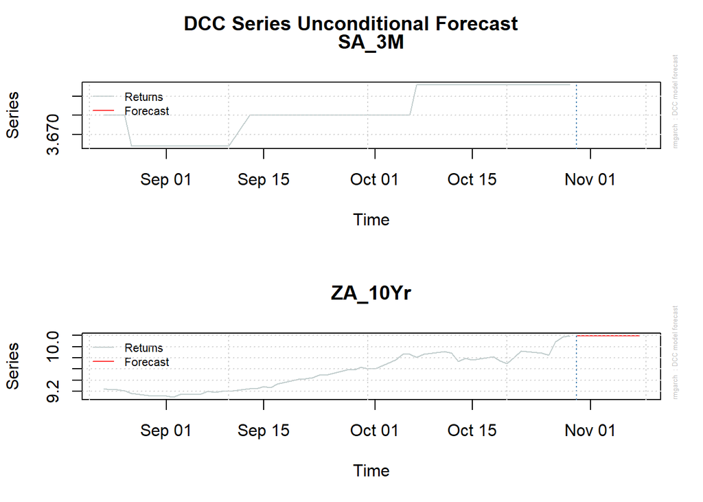

Figure 25 DCC Series Unconditional Forecast

```r
plot(dccf1, which=1, main = "DCC")
```

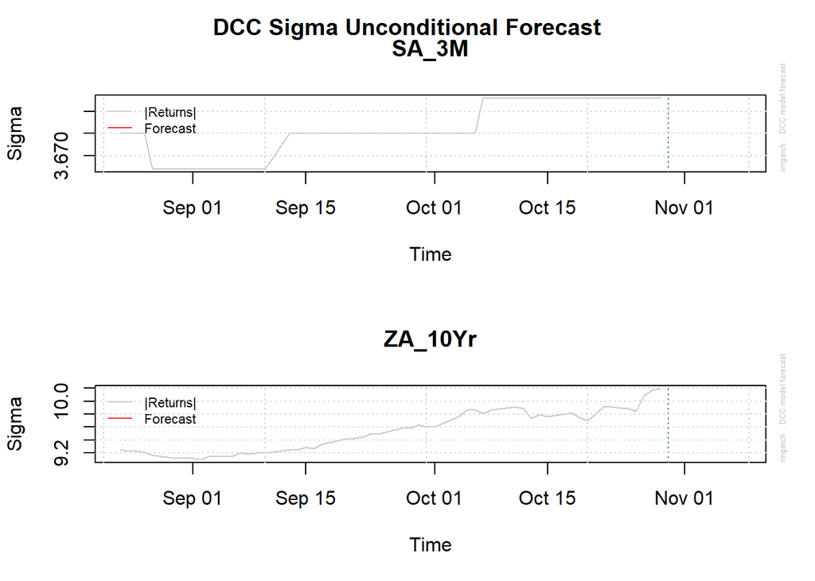

Figure 26 DCC Sigma Unconditional Forecast

```r
plot(dccf1, which=2, size = 400, ax.lab = 1.9,
     cex.axes = 1, cex.main = 0.05, cex.sub = 2)
```

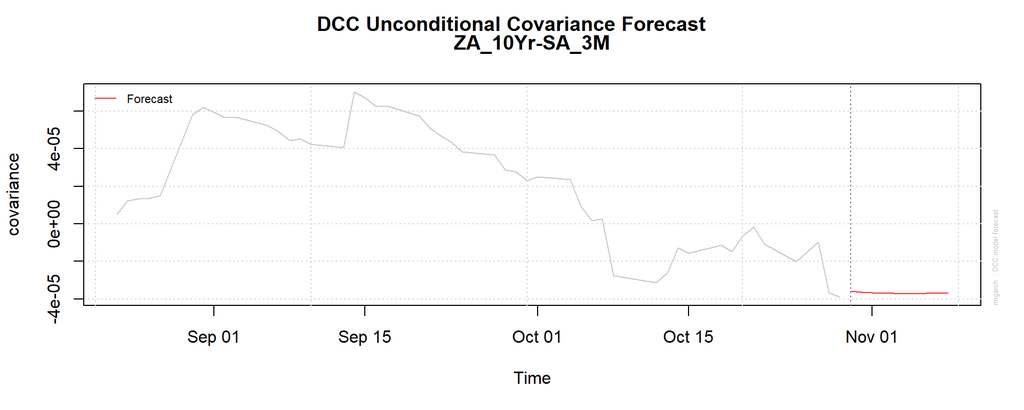

Figure 27 DCC Unconditional Covariance Forecast

```r
plot(dccf1, which=3, cex.main = 0.05)
```

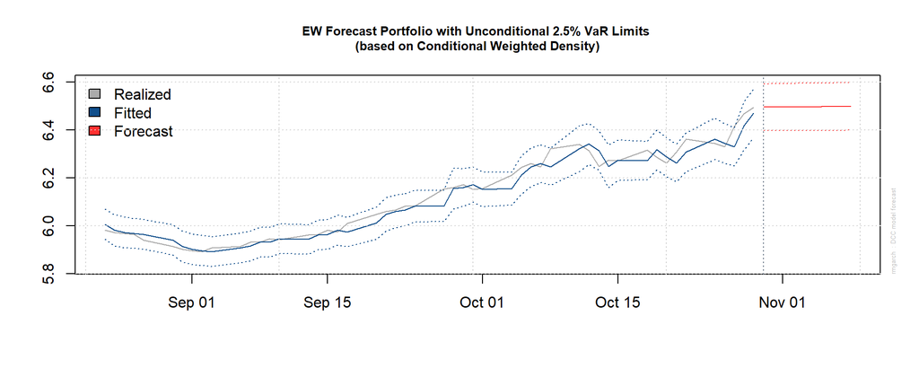

Figure 28 EW Forecast Portfolio with Unconditional limits

```r
plot(dccf1, which= 5, main = "DCC ")
```

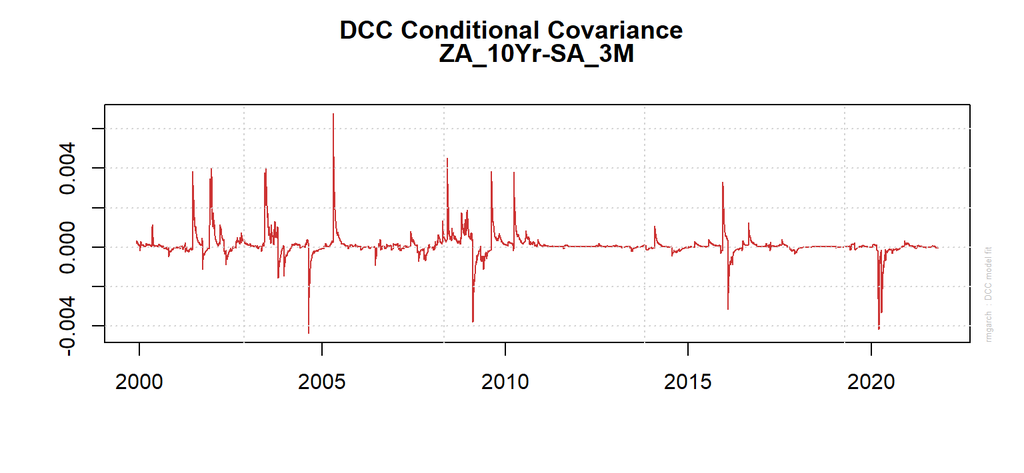

Figure 31 DCC Conditional Covariance

```r
plot(fit1, which=3, series=c(1,2))
```